# W06-Reflection Essay-Introduction to Positron

Author

Lucynda Young

Published

March 3, 2026

# 1 Introduction

# 2 Introduction

This reflection documents my experience installing and using **Positron**, exploring AI integration, and publishing a Quarto report to GitHub Pages.

# 3 1. Project Setup in Positron

## 3.1 Prompt

> Start a new project and Quarto file (.qmd) inside Positron.  
> Create a folder called “Reflection-assignments” and organize the file structure properly.  
> Start a new project by opening that folder.  
> Create and save the qmd file with the required YAML header. ## Response

Creating a project folder ensures: - Reproducibility  
- Organized file management  
- Easy GitHub publishing  
- Clean project environment

**Tip**

Opening the folder itself (instead of just a file) ensures Positron recognizes it as a project.

# 4 2. Preparing the HTML Report Using Quarto

## 4.1 Prompt

> Implement as many HTML features and effects as possible.

## 4.2 Response

This report demonstrates the following Quarto features:

## 4.3 Example: R Code Execution

```r
# Simple calculation example
mean(cars$speed)
```

```
[1] 15.4
```

```r
#| echo: false
summary(cars)
```

```
     speed           dist
 Min.   : 4.0   Min.   :  2.00
 1st Qu.:12.0   1st Qu.: 26.00
 Median :15.0   Median : 36.00
 Mean   :15.4   Mean   : 42.98
 3rd Qu.:19.0   3rd Qu.: 56.00
 Max.   :25.0   Max.   :120.00
```

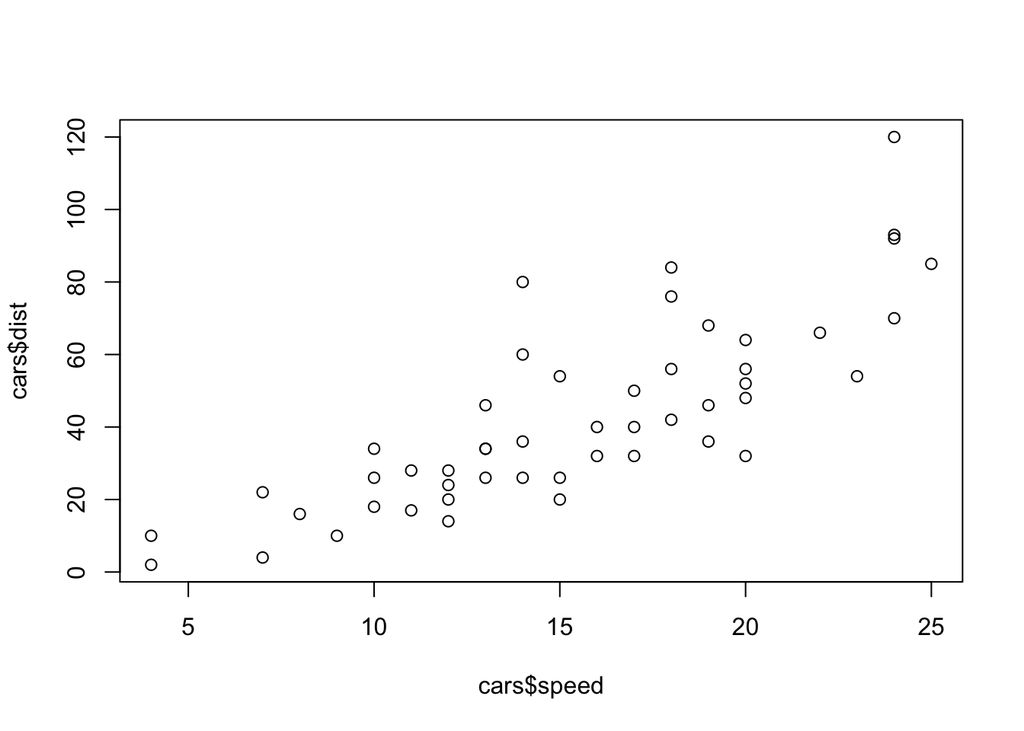

```r
#| label: fig-speed
#| fig-cap: "Speed vs Stopping Distance"
plot(cars$speed, cars$dist)
```

Blockquote Example

> Positron integrates AI directly into the IDE, making coding more interactive and efficient.

# 5 Essay Reflection 3.1 Installing and Exploring Positron Prompt

Download and install Positron. Follow the videos in Step 1 and Step 3.

Response

- After downloading Positron, I followed along with the tutorial videos. I practiced:
- Creating projects
- Running R code
- Rendering Quarto files
- Exploring AI tools
- The interface felt cleaner and more modern than RStudio.

# 6 3.2 What I Like About Positron Compared with RStudio Prompt

What do you like about Positron compared with RStudio?

Response

Compared to RStudio, I prefer Positron because:

- AI is integrated directly into the IDE
- The interface feels less cluttered
- Quarto rendering is seamless
- Publishing workflows are streamlined
- RStudio feels stable and familiar, but Positron feels designed for modern AI-supported workflows.

# 7 AI Integration in Positron {#sec-ai} Prompt

Describe how AI can be used inside Positron.

Response

AI inside Positron can assist with:

- Code completion
- Code explanation
- Debugging
- Writing documentation
- Generating Quarto content
- Refactoring code
- Some AI features are free (limited tier), while others require subscription services.

# 8 GitHub Copilot Experience

I applied for the GitHub Copilot Education plan and waiting to be approved.

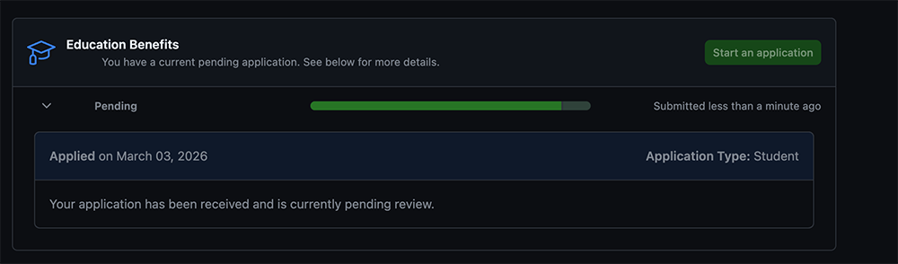

Autocompleting repetitive code

Generating function templates

Speeding up documentation writing

However, I noticed that over-reliance could reduce deep thinking. When used intentionally, it enhances productivity without replacing critical thinking.

**Warning**

AI should support learning, not replace analytical reasoning.

# 9 Publishing to GitHub Pages Prompt

Publish this report to GitHub Pages and provide a URL.

Response

To publish this report, I:

- Created a GitHub repository
- Pushed my .qmd and .html files
- Enabled GitHub Pages in repository settings
- Selected the main branch

GitHub Pages hosts rendered HTML files, while GitHub repositories store source code.

# 10 Conclusion

This module strengthened my ability to:

Create organized Positron projects

Write professional Quarto reports

Integrate AI into coding workflows

Publish content using GitHub Pages

I now feel confident using Positron as a modern data science and publishing environment.